# Inferência Bayesiana 1

Diogo Melo  
2026-10-09

# Definindo uma posterior muito simples

Considere o seguinte modelo. No primeiro exemplo, vamos considerar o desvio-padrão conhecido e fixá-lo em 1. Assim, o único parâmetro desconhecido é a média $\mu$.

Verossimilhança:

$$y_i \sim Normal(\mu, \sigma = 1)$$

Distribuição a priori:

$$\mu \sim Normal(0, 1)$$

Para modelos muito simples, como este, podemos escrever e calcular a posterior diretamente. Em seguida, usamos os valores calculados para representar a distribuição posterior completa.

No código a seguir, escrevemos essa posterior em R. Percorremos os valores possíveis de $\mu$ e calculamos sua densidade probabilística posterior usando o produto entre a distribuição a priori e a verossimilhança (ou a soma, na escala logarítmica). Isso revela a forma da distribuição posterior, que podemos representar e examinar para tirar conclusões.

```r
set.seed(2)
# Dados:
y = rnorm(100, mean = 2, sd = 1)

# Log-posterior de mu, com sigma conhecido e fixado em 1
logP_mu_y = function(mu, data = y){
  ll = sum(dnorm(data, mean = mu, sd = 1, log = TRUE))
  logprior = dnorm(mu, mean = 0, sd = 1, log = TRUE)
  logprior + ll
}
```

Neste caso univariado, é fácil avaliar muitos valores possíveis de $\mu$ e identificar aqueles com maior probabilidade. Em dimensões elevadas, porém, essa estratégia deixa de ser viável.

```r
x = seq(1, 3, 0.01)
log_posterior = Vectorize(logP_mu_y)(x)
posterior_density = exp(log_posterior - max(log_posterior))
posterior_density = posterior_density / sum(posterior_density * diff(x)[1])
plot(posterior_density ~ x, type = "l", lwd = 2, col = 2,
     xlab = "Média (mu)", ylab = "Densidade posterior")
abline(v = 2, lty = 2)
```

Com base nessa posterior, qual é o valor mais provável do parâmetro? Altere os parâmetros da distribuição a priori e veja como a posterior se comporta.

## Quando o desvio-padrão também é desconhecido

Agora vamos usar os mesmos dados, mas tratar $\sigma$ como um parâmetro desconhecido. Atribuímos a ele uma distribuição a priori exponencial com taxa 1. Como os parâmetros são contínuos, avaliamos a densidade numa grade suficientemente fina de combinações de $\mu$ e $\sigma$. Essa avaliação exaustiva da grade aproxima a superfície da posterior conjunta.

```r
logP_mu_sigma_y = function(mu, sigma, data = y){
  ll = sum(dnorm(data, mean = mu, sd = sigma, log = TRUE))
  logprior_mu = dnorm(mu, mean = 0, sd = 1, log = TRUE)
  logprior_sigma = dexp(sigma, rate = 1, log = TRUE)
  ll + logprior_mu + logprior_sigma
}

mu_grid = seq(1, 3, length.out = 250)
sigma_grid = seq(0.1, 3, length.out = 250)
parameter_grid = expand.grid(mu = mu_grid, sigma = sigma_grid)
log_posterior_grid = mapply(
  logP_mu_sigma_y,
  mu = parameter_grid$mu,
  sigma = parameter_grid$sigma
)

posterior_density = exp(log_posterior_grid - max(log_posterior_grid))
posterior_density = posterior_density /
  sum(posterior_density * diff(mu_grid)[1] * diff(sigma_grid)[1])
parameter_grid$posterior_density = posterior_density

library(ggplot2)

ggplot(parameter_grid,
    aes(x = mu, y = sigma, fill = posterior_density)) +
  geom_raster() +
  coord_cartesian(xlim = c(1.5, 2.3), ylim = c(0.9, 1.4)) +
  scale_fill_viridis_c(name = "Densidade posterior", option = "A") +
  labs(x = "Média (mu)", y = "Desvio-padrão (sigma)")
```

[output not shown]

# Instalando o pacote `rethinking`

Estas instruções foram adaptadas de https://github.com/rmcelreath/rethinking. Consulte o site para obter mais detalhes e conhecer outras opções.

O processo tem três etapas: (1) instalar as ferramentas de compilação C++; (2) instalar `cmdstanr`; e (3) instalar `rethinking`. Os detalhes estão abaixo.

Primeiro, instale as ferramentas de compilação C++. Acesse [mc-stan.org/docs/cmdstan-guide/cmdstan-installation.html](https://mc-stan.org/docs/cmdstan-guide/cmdstan-installation.html#cpp-toolchain) e siga as instruções para sua plataforma.

Em seguida, instale o pacote `cmdstanr`. Consulte https://mc-stan.org/cmdstanr/ para obter mais informações. Para instalá-lo, execute:

```
install.packages("cmdstanr", repos = c('https://stan-dev.r-universe.dev', getOption("repos")))
```

Na primeira instalação do `cmdstanr`, também será necessário compilar as bibliotecas com `cmdstanr::install_cmdstan()`. Esse trabalho inicial vale a pena e só precisa ser feito uma vez.

Por fim, instale `rethinking` no R com:

```
install.packages(c("coda","mvtnorm","remotes","loo","dagitty","shape","rstanarm"))
remotes::install_github("rmcelreath/rethinking")
```

O pacote `rethinking` não está no CRAN; ele é distribuído pelo GitHub. Se aparecer uma mensagem dizendo que o pacote não está disponível para sua versão do R, confira se você tentou instalá-lo pelo CRAN. Use o comando para instakação a partir do GitHub, mostrado acima.

# Especificando um modelo com o pacote `rethinking`

A sintaxe de `rethinking` se aproxima bastante da notação matemática usada em aula. Por exemplo, podemos especificar uma regressão linear simples de $y_i$ em $x_i$ com distribuições a priori razoáveis:

$$\begin{aligned}
y_i &\sim Normal(\mu_i, \sigma) \\
\mu_i &= \alpha + \beta x_i \\
\alpha &\sim Normal(0, 1) \\
\beta &\sim Normal(0, 1) \\
\sigma &\sim Exponential(1) \\
\end{aligned}$$

Primeiro, vamos visualizar as distribuições a priori assumidas para os três parâmetros.

Distribuição normal com $\mu = 0$ e $\sigma = 1$:

```r
curve(dnorm(x, mean = 0, sd = 1), -3, 3, lwd = 2, col = 2,
            ylab = "Densidade", xlab = "Valor do parâmetro")
```

Distribuição exponencial com $\lambda = 1$:

```r
curve(dexp(x, rate = 1), 0, 3, lwd = 2, col = 2,
            ylab = "Densidade", xlab = "Valor do parâmetro" )
```

O que essas distribuições a priori nos dizem? Que valores são considerados plausíveis para esses parâmetros?

Agora, vamos simular alguns dados:

```r
N = 100 # tamanho da amostra

# Parâmetros da regressão linear
alpha = 1 # Intercepto
beta = 1  # Inclinação em relação a x
## Simula uma resposta normal cuja média é uma função linear de um preditor
x = rnorm(N)           # Variável preditora simulada: média = 0 e desvio-padrão = 1
mu = alpha + beta * x  # Modelo linear para o valor esperado
y = rnorm(N, mu)       # Variável resposta, com desvio-padrão residual igual a 1
```

Agora, vamos ajustar o modelo, que pode ser escrito no código da seguinte forma:

```r
library(rethinking)

## Código do `rethinking`
m1 = quap(alist(
  y ~ dnorm(mu, sigma),     # Verossimilhança
  mu <- a + b * x,          # Modelo linear
  a ~ dnorm(0, 1),          # Distribuição a priori do intercepto
  b ~ dnorm(0, 1),          # Distribuição a priori da inclinação
  sigma ~ dexp(1)),         # Distribuição a priori do desvio-padrão residual
  data = list(y = y, x = x) # Lista de dados
)
```

A função `precis()` gera uma tabela com resumo das estimativas dos coeficientes:

```r
precis(m1, digits = 2, prob = 0.93) # Resumo do ajuste
```

**Exercício:** ajuste o mesmo modelo com a função `lm()` do R e compare os resumos dos dois modelos.

Quando a amostra é grande, a verossimilhança tende a dominar a distribuição a priori; por isso, até distribuições a priori mais informativas podem levar a conclusões semelhantes.

**Exercício:** altere as distribuições a priori. Você consegue encontrar uma que mude substancialmente as estimativas? Em seguida, reduza o tamanho da amostra, alterando `N`. As distribuições a priori fazem mais diferença agora?

# Ajustando modelos com métodos bayesianos

Nos tutoriais anteriores, ajustamos modelos lineares pelo método OLS. Agora, vamos ajustar o mesmo modelo usando algumas abordagens diferentes e comparar as estimativas de cada uma. Vamos usar OLS; o pacote `rstanarm`, que utiliza a mesma sintaxe de fórmulas da função `lm()`, mas com uma maquinaria bayesiana; e o pacote `rethinking`, que permite especificar modelos de forma mais explícita.

A abordagem bayesiana para a regressão linear se baseia na distribuição posterior dos parâmetros $\alpha$ e $\beta$. Essa posterior é proporcional ao produto entre a verossimilhança dos dados, condicionada aos parâmetros, e as distribuições a priori dos parâmetros.

A verossimilhança dos dados, dados os parâmetros, é igual à obtida com o ajuste OLS. Em geral, atribuímos aos parâmetros distribuições a priori normais, com média zero e desvio-padrão fixo.

Vamos gerar um novo conjunto de dados com parâmetros conhecidos para ilustrar algumas diferenças entre os métodos OLS e bayesiano.

```r
set.seed(4)

x = runif(50, 50, 100)
y = 1000 + 150 * x + rnorm(50, 0, 1000)
data = data.frame(x, y)
```

Sempre visualize os dados antes de ajustar um modelo.

```r
plot(y ~ x, data = data)
```

Primeiro, vamos ajustar o modelo pelo método OLS:

```r
mod_ols <- lm(y ~ x, data = data)

# A função summary fornece várias informações sobre o modelo,
# incluindo estimativas, erros-padrão, valores-p para os coeficientes
# e o desvio-padrão residual (sigma).
summary(mod_ols)
```

Agora, vamos ajustar o modelo com o pacote `rstanarm`, que utiliza a linguagem Stan e fornece um conjunto padrão de distribuições a priori fracamente informativas.

```r
suppressPackageStartupMessages(library(rstanarm))
mod_bayesian <- stan_glm(y ~ x, data = data)

summary(mod_bayesian)
```

Vamos comparar as estimativas dos coeficientes obtidas pelos dois métodos.

```r
coef(mod_ols)
coef(mod_bayesian)

library(ggplot2)

# Extrai o intercepto e a inclinação dos dois modelos
ols_intercept <- coef(mod_ols)[1]
ols_slope <- coef(mod_ols)[2]
bayesian_intercept <- coef(mod_bayesian)[1]
bayesian_slope <- coef(mod_bayesian)[2]


ggplot(data, aes(x, y)) +
  geom_point() +
  geom_abline(intercept = ols_intercept, slope = ols_slope, color = "red", linetype = "solid") +
  geom_abline(intercept = bayesian_intercept, slope = bayesian_slope, color = "blue", linetype = "dashed") +
  theme_bw()
```

Quão semelhantes são as estimativas dos dois métodos?

## Especificando o modelo explicitamente com `rethinking`

Agora, vamos usar o pacote `rethinking` para ajustar o modelo com algumas das distribuições a priori padrão usadas em aula.

```r
suppressPackageStartupMessages(library(rethinking))

mod_rethinking = quap(
  alist(
    y ~ dnorm(mu, sigma),
    mu <- a + b * x,
    a ~ dnorm(0, 1),
    b ~ dnorm(0, 1),
    sigma ~ dexp(1)
  ),
  data = data
)
precis(mod_rethinking)
```

[output not shown]

Isso acontece porque as distribuições a priori que usamos no código de `rethinking` (normais padrão) estão muito distantes dos valores verdadeiros dos parâmetros. Uma forma de evitar esse problema é padronizar as variáveis antes de ajustar o modelo. O pacote `rstanarm` resolve isto ajustando a escala das distribuições a priori à escala do ados. Como estamos trabalhando com o pacote `rethinking` e montando nossos modelos de forma mais artesanal, precisamos pensar nesse tipo de questão.

```r
data$x_scaled = as.numeric(scale(data$x))
data$y_scaled = as.numeric(scale(data$y))

mod_rethinking_scaled = quap(
  alist(
    y_scaled ~ dnorm(mu, sigma),
    mu <- a + b * x_scaled,
    a ~ dnorm(0, 1),
    b ~ dnorm(0, 1),
    sigma ~ dexp(1)
  ),
  data = data
)
mod_stanarm_scaled = stan_glm(y_scaled ~ x_scaled, data = data)
mod_ols_scaled = lm(y_scaled ~ x_scaled, data = data)
```

Agora, vamos comparar as estimativas dos modelos.

```r
coef(mod_ols_scaled)
coef(mod_stanarm_scaled)
coef(mod_rethinking_scaled)
```

Padronizar as variáveis é uma boa prática ao ajustar modelos bayesianos. O escalonamento melhora a eficiência computacional e facilita a definição de distribuições a priori razoáveis.

# Estendendo a regressão linear

Podemos estender a regressão linear simples para incluir vários preditores. Esses são os modelos de **regressão linear múltipla**, dos quais a regressão simples é um caso particular, com apenas um preditor.

Nas próximas seções, vamos ajustar modelos de regressão múltipla com o pacote `rethinking`, interpretar seus coeficientes e visualizar os resultados.

# Modelo linear múltiplo aditivo

Em uma regressão linear múltipla aditiva, o valor esperado da resposta, $\mu$, é a soma dos efeitos de vários preditores $X_i$, cada um ponderado por seu próprio coeficiente $\beta_i$:

$$\begin{aligned}
y_i &\sim Normal(\mu_i, \sigma) \\
\mu_i & = \alpha + \beta_1 x_{i1} + \beta_2 x_{i2} + \dots + \beta_k x_{ik}\\
\end{aligned}$$

## Ajustando o modelo

Vamos usar dados da planta bienal *Ipomopsis aggregata*. Quarenta plantas foram distribuídas entre dois tratamentos: sem proteção contra herbivoria e protegidas da herbivoria. Para cada planta, mediram-se a produção de frutos e o diâmetro do caule na base.

Prepare os dados:

```r
df <- read.csv("https://raw.githubusercontent.com/lmmx/crawley-r-statistics-book-notes/master/code/ipomopsis.csv")
names(df) <- c("Root", "Fruit", "Grazing")
df$Root <- as.numeric(scale(df$Root, center = TRUE, scale = TRUE))
df$Fruit <- as.numeric(scale(df$Fruit, center = TRUE, scale = TRUE))

# Plantas sem proteção são o controle; as protegidas por cerca recebem o tratamento:
df$Grazing0 <- ifelse(df$Grazing == "Ungrazed", 1, 0)
```

Ajuste o modelo aditivo com `rethinking`:

```r
# Ajusta o modelo usando quap
m1 <- quap(
  alist(
    Fruit ~ dnorm(mu, sigma),
    mu <- a + b * Grazing0 + c * Root,
    a ~ dnorm(0, 1),
    b ~ dnorm(0, 1),
    c ~ dnorm(0, 1),
    sigma ~ dexp(1)
  ),
  data = df
)
```

Extraia e resuma os coeficientes:

```r
precis(m1)

m1_coef <- precis(m1)[1]
```

## Visualizando previsões

Crie um gráfico com os dados observados e os valores previstos:

```r
# Representa os dados observados
plot(df$Fruit ~ df$Root,
     col = ifelse(df$Grazing0 == 1, "red", "black"),
     pch = ifelse(df$Grazing0 == 1, 17, 16),
     xlab = "Diâmetro basal (escore z)",
     ylab = "Massa seca dos frutos (escore z)")

# Adiciona as retas previstas: as duas retas compartilham a inclinação c
# e diferem no intercepto pelo efeito do tratamento, b
abline(a = m1_coef["a", ], b = m1_coef["c", ], col = "black", lwd = 2)
abline(a = m1_coef["a", ] + m1_coef["b", ], b = m1_coef["c", ], col = "red", lwd = 2)

# Adiciona a legenda
legend("topleft", legend = c("Protegidas (cerca)", "Controle"), col = c("red", "black"),
       pch = c(17, 16), lty = 1, bty = "n")
```

## Comparando a magnitude dos coeficientes

O gráfico de `precis` resume as distribuições posteriores dos coeficientes:

```r
plot(precis(m1))
```

O coeficiente `b` corresponde à diferença entre os tratamentos codificados como 0 e 1. Já `c` corresponde à mudança esperada na produção de frutos associada a um aumento de um desvio-padrão no diâmetro, pois `Root` foi padronizada. Como os preditores estão em escalas diferentes, não podemos comparar diretamente a magnitude desses dois coeficientes.

### Desvio-padrão de uma variável binária

Considere uma variável binária $X$, codificada como 0 e 1, cuja probabilidade de assumir o valor 1 é $p$. Sua esperança é $E[X]=p$ e, como $X^2=X$, sua variância é:

$$\begin{aligned}
\mathrm{Var}(X) &= E[X^2] - E[X]^2 \\
&= p - p^2 \\
&= p(1-p).
\end{aligned}$$

Portanto, $\mathrm{sd}(X)=\sqrt{p(1-p)}$. Quando os grupos têm frequências aproximadamente iguais, $p\approx0{,}5$, o desvio-padrão da codificação 0/1 é aproximadamente $0{,}5$. Podemos recodificar o contraste usando a transformação z, que padroniza a variável para ter média zero e desvio-padrão 1. A transformação z de $X$ é:

$$C = \frac{X-E[X]}{\mathrm{sd}(X)}
= \frac{X-p}{\sqrt{p(1-p)}}.$$

Quando $p=0{,}5$, essa transformação altera os valores do preditor de $0$ e $1$ para $-1$ e $1$.

Com essa codificação e grupos aproximadamente equilibrados, o coeficiente $b$ representa a mudança esperada por um desvio-padrão do preditor e pode ser comparado, em magnitude, ao coeficiente de `Root`, também medido na escala de desvio-padrão. O coeficiente $b$ passa a ser metade da diferença entre as médias dos grupos. Essa recodificação muda a escala do coeficiente, não o ajuste do modelo. A vantagem de usar essa codificação dos dois tratamentos é que agora o coeficiente do tratamento e o coeficiente associado ao diâmetro das plantas podem, potencialmente[^2], ser comparados diretamente. Ajuste o modelo novamente e interprete os coeficientes. Usando essa escala comparável e supondo que os efeitos sejam boas estimativas causais, qual dos dois efeitos tem maior influência na resposta?

```r
df$Grazing_contrast <- ifelse(df$Grazing0 == 1, 1, -1)
```

## Modelando a variabilidade residual

Neste modelo, e até agora no curso, sempre usamos a versão mais simples do ajuste da regressão linear, que assume que a variabilidade residual é constante para todos os valores de $x$. Essa suposição é chamada de **homocedasticidade**. Quando a variabilidade residual muda com o valor do preditor, dizemos que há **heterocedasticidade**. Vamos tentar modelar a variabilidade residual como uma função do preditor. Para isso, vamos incluir um modelo explícito para o desvio-padrão residual em função do tratamento experimental, de forma exatamente análoga à maneira como modelamos a média da resposta.

$$\begin{aligned}
y_i &\sim Normal(\mu_i, \sigma_i) \\
\mu_i &= a_{t[i]} + c * \text{Root} \\
\sigma_i &= \gamma_{t[i]} \text{, onde } t[i] \text{ é o tratamento da i-ésima observação} \\
a[t] &\sim Normal(0, 1) \\
c &\sim Normal(0, 1) \\
\gamma[t] &\sim Exponential(1) \\
\end{aligned}$$

Esse modelo usa uma estratégia de codificação do tratamento levemente diferente da usada anteriormente, mas equivalente a ela. Agora, vamos usar um vetor de índices para indicar o grupo de cada observação. Esse vetor, que vai conter os valores 1 e 2, será usado para indexar os dois vetores que armazenam os interceptos e os desvios-padrão residuais, um para cada grupo. A vantagem dessa abordagem é que ela pode ser facilmente estendida para mais de dois grupos. Podemos usar essa estratégia aqui graças à flexibilidade do pacote `rethinking`; ela seria equivalente ao uso de contrastes com codificação *one-hot* em funções como `rstanarm` e `lm()`.

```r
df$Grazing_i <- ifelse(df$Grazing0 == 1, 2, 1)

m_heteroskedastic <- quap(
  alist(
    Fruit ~ dnorm(mu, sigma[Grazing_i]),
    mu <- a[Grazing_i] + c * Root,
    a[Grazing_i] ~ dnorm(0, 1),
    c ~ dnorm(0, 1),
    sigma[Grazing_i] ~ dexp(1)
  ),
  data = df
)

precis(m_heteroskedastic, depth = 2)
```

O índice `Grazing_i` associa cada observação a um dos dois grupos. O modelo usa esse índice para selecionar tanto o intercepto quanto o desvio-padrão residual correspondentes, enquanto a inclinação de `Root` é compartilhada. Assim, `sigma` contém um parâmetro para cada tratamento, em vez de um único desvio-padrão comum a todas as plantas. Como o modelo usa parâmetros armazenados em vetores, precisamos usar o argumento `depth = 2` na função `precis()` para que ela mostre os dois interceptos e os dois desvios-padrão residuais. Compare os valores estimados de `a` com os valores obtidos no modelo anterior. O que mudou? Compare os desvios-padrão residuais estimados para cada grupo. Há evidência de diferença na variabilidade residual entre os dois grupos?

### Testando a diferença na variabilidade residual entre os grupos

Para testar a diferença na variabilidade residual entre os grupos, podemos extrair amostras da posterior e calcular a diferença entre os dois desvios-padrão residuais. Em seguida, podemos calcular a proporção de amostras em que o desvio-padrão do grupo protegido é maior que o desvio-padrão do grupo não protegido (ou vice-versa).

```r
posterior_samples <- extract.samples(m_heteroskedastic, n = 1000)
sigma1 <- posterior_samples$sigma[,1]
sigma2 <- posterior_samples$sigma[,2]
difference <- sigma1 - sigma2
hist(difference, breaks = 30, main = "Diferença entre desvios-padrão residuais", xlab = "sigma1 - sigma2")
abline(v = 0, col = "red", lwd = 2)
proportion <- mean(difference > 0)
proportion
```

É importante fazer essa comparação explícita entre os coeficientes, já que a comparação visual entre os intervalos de credibilidade pode ser enganosa. Mesmo que os intervalos se sobreponham, ainda pode haver uma diferença entre os grupos devido a correlações entre as estimativas dos dois parâmetros. A proporção calculada acima nos dá uma medida direta da evidência de diferença na variabilidade residual entre os grupos.

**Exercício opcional**: ajuste o modelo introduzindo uma dependência entre a variância residual e o diâmetro basal das plantas. Por exemplo, podemos modelar o desvio-padrão residual como uma função não linear do diâmetro basal, como uma lei de potência com dois parâmetros. Existem diversas estratégias, mas todas devem lidar com o fato de que o desvio-padrão residual deve ser positivo.[^3] Compare os resultados com o modelo anterior.

# Regressão robusta

Uma vantagem dos métodos bayesianos é poder adaptar os modelos mantendo a sintaxe usada nos exemplos simples. Essa flexibilidade pode ser usada para criar modelos sob medida para problemas específicos.

Vamos ilustrar essa ideia com a regressão robusta. Em modelos lineares, observações atípicas (*outliers*) podem resultar de erros de medição ou de processos biológicos reais que produzem valores fora da faixa esperada por uma distribuição normal. Nesse segundo caso, excluí-las pode descartar informação importante.

Para ilustrar, vamos usar um conjunto de dados em que algumas espécies extremas alteram as estimativas de uma regressão simples.

## Observações de alta influência em dados reais

O conjunto `Animals`, do pacote `MASS`, contém as massas corporal e cerebral de 28 espécies de animais terrestres. Vamos modelar o logaritmo da massa cerebral como uma função linear do logaritmo da massa corporal, uma relação alométrica simples usada para comparar espécies. O conjunto inclui grandes dinossauros cujas medidas são claramente discordantes das demais. Essas espécies têm massas corporais muito altas e massas cerebrais relativamente baixas, o que as torna observações destoantes das demais.

Primeiro, vamos visualizar os dados:

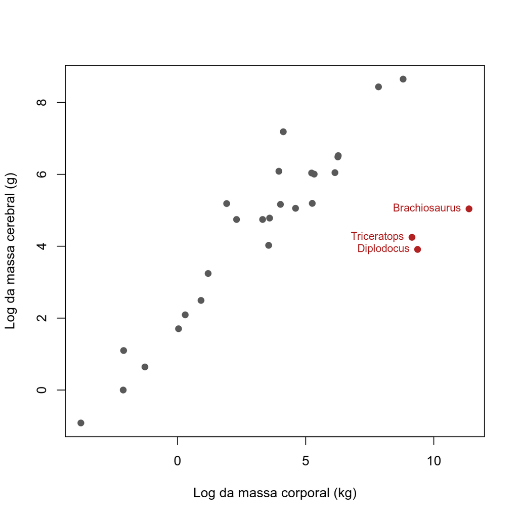

```r
animals <- MASS::Animals
animals$log_body <- log(animals$body)
animals$log_brain <- log(animals$brain)
body_center <- mean(animals$log_body)
animals$log_body_c <- animals$log_body - body_center
large_dinosaurs <- c("Brachiosaurus", "Dipliodocus", "Triceratops")
dinosaur_labels <- c("Brachiosaurus", "Diplodocus", "Triceratops")
dinosaur_indices <- match(large_dinosaurs, rownames(animals))
animals_without_dinosaurs <- animals[-dinosaur_indices, ]
point_colors <- ifelse(seq_len(nrow(animals)) %in% dinosaur_indices,
                       "firebrick", "grey35")

plot(log_brain ~ log_body, data = animals, pch = 19, col = point_colors,
  xlab = "Log da massa corporal (kg)", ylab = "Log da massa cerebral (g)")
text(animals$log_body[dinosaur_indices], animals$log_brain[dinosaur_indices],
     labels = dinosaur_labels, pos = 2, col = "firebrick", cex = 0.8)
```

Como você espera que a inclusão dessas espécies influencie a inclinação da reta ajustada? E o desvio-padrão residual?

## Ajustando os modelos com `ulam`

Ajuste a mesma regressão gaussiana com todas as espécies e com os dados sem os três dinossauros. Os dois modelos usam as mesmas distribuições a priori fracamente informativas.

```r
suppressPackageStartupMessages(library(rethinking))

m_animals_all <- ulam(
  alist(
    log_brain ~ dnorm(mu, sigma),
    mu <- a + b * log_body_c,
    a ~ dnorm(0, 1),
    b ~ dnorm(0, 1),
    sigma ~ dexp(1)
  ),
  data = animals,
  chains = 4, cores = 4, iter = 2000, refresh = 0
)

m_animals_without_dinosaurs <- ulam(
  alist(
    log_brain ~ dnorm(mu, sigma),
    mu <- a + b * log_body_c,
    a ~ dnorm(0, 1),
    b ~ dnorm(0, 1),
    sigma ~ dexp(1)
  ),
  data = animals_without_dinosaurs,
  chains = 4, cores = 4, iter = 2000, refresh = 0
)
```

```r
precis(m_animals_all, digits = 2)
precis(m_animals_without_dinosaurs, digits = 2)
```

Compare as estimativas posteriores da inclinação `b` e do desvio-padrão residual `sigma`. Quanto elas mudam quando os três dinossauros são retirados? Esta é uma análise de sensibilidade, não uma evidência de que essas espécies devam ser descartadas.

## Visualizando a influência no ajuste

O código abaixo mostra graficamente as médias posteriores dos dois modelos no mesmo gráfico de dispersão. As espécies destacadas estão incluídas no ajuste com todos os dados e são excluídas juntas no segundo ajuste.

```r
posterior_all <- extract.samples(m_animals_all)
posterior_without_dinosaurs <- extract.samples(m_animals_without_dinosaurs)
body_values <- seq(min(animals$log_body), max(animals$log_body), length.out = 100)
body_values_c <- body_values - body_center
point_colors <- ifelse(seq_len(nrow(animals)) %in% dinosaur_indices,
                       "firebrick", "grey35")

plot(log_brain ~ log_body, data = animals, pch = 19, col = point_colors,
  xlab = "Log da massa corporal (kg)", ylab = "Log da massa cerebral (g)")
text(animals$log_body[dinosaur_indices], animals$log_brain[dinosaur_indices],
     labels = dinosaur_labels, pos = 2, col = "firebrick", cex = 0.8)
lines(body_values,
      mean(posterior_all$a) + mean(posterior_all$b) * body_values_c,
      col = "navy", lwd = 2)
lines(body_values,
      mean(posterior_without_dinosaurs$a) +
        mean(posterior_without_dinosaurs$b) * body_values_c,
      col = "darkorange3", lwd = 2, lty = 2)
legend("topleft",
       legend = c("Todas as espécies", "Sem os grandes dinossauros", "Grandes dinossauros"),
       col = c("navy", "darkorange3", "firebrick"),
       lty = c(1, 2, NA), pch = c(NA, NA, 19), bty = "n")
```

O que acontece com a inclinação quando os três dinossauros são retirados? Antes de excluir espécies influentes, investigue as medidas e considere se uma única reta alométrica é adequada para mamíferos e dinossauros.

# Modificando o modelo para reduzir a sensibilidade a observações atípicas

Uma vantagem da modelagem bayesiana é que podemos mudar a distribuição dos resíduos sem alterar o preditor linear. Um modelo com caudas mais pesadas pode reduzir a influência de observações muito distantes da reta ajustada.

Algumas observações atípicas são erros de medição; outras são observações legítimas de processos biológicos com variação mais extrema do que a permitida por um modelo gaussiano. Excluir uma observação legítima pode descartar informação importante. Em vez disso, vamos manter os três dinossauros e substituir a distribuição gaussiana dos resíduos por uma distribuição $t$ de Student. Em seguida, vamos comparar a sensibilidade dos modelos, ajustando cada um com e sem essas espécies.

## Entendendo a distribuição $t$ de Student

Na distribuição $t$, o parâmetro $\nu$ (graus de liberdade, letra grega “nu”) controla o peso das caudas. Uma intuição útil é pensar que a $t$ combina uma normal com uma variância incerta. Essa incerteza sobre a variância permite que alguns valores fiquem muito mais dispersos do que outros. Com $\nu$ baixo, essa incerteza é maior e valores extremos recebem mais probabilidade. Com $\nu$ alto, a variância fica mais concentrada e a $t$ se aproxima da normal.

O gráfico compara distribuições com a mesma localização e escala. A escala vertical logarítmica deixa visível a diferença entre as caudas.

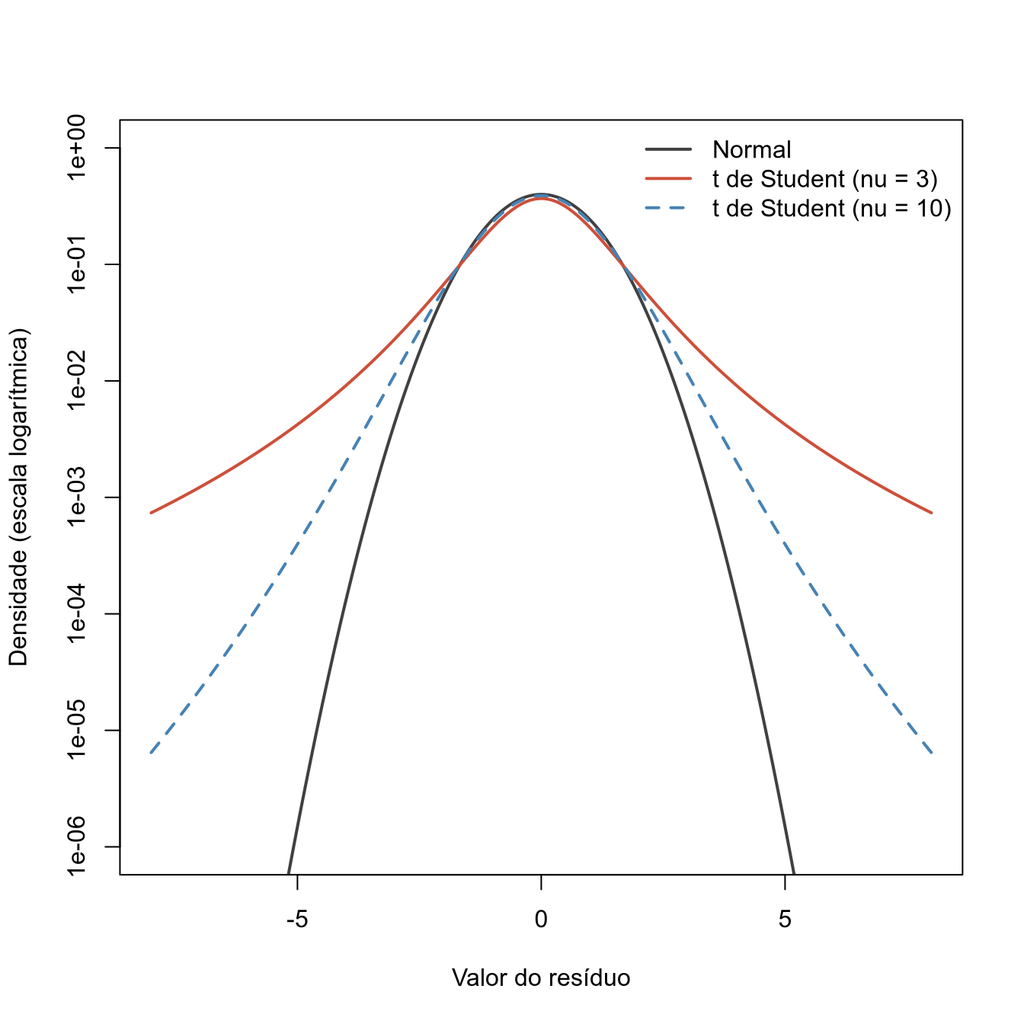

```r
x <- seq(-8, 8, length.out = 1000)
curve_normal <- dnorm(x)
curve_t_low <- dt(x, df = 3)
curve_t_high <- dt(x, df = 10)
curve_colors <- c("gray25", "tomato3", "steelblue")

plot(x, curve_normal, type = "l", log = "y", ylim = c(1e-6, 1),
     col = curve_colors[1], lwd = 2,
     xlab = "Valor do resíduo", ylab = "Densidade (escala logarítmica)")
lines(x, curve_t_low, col = curve_colors[2], lwd = 2)
lines(x, curve_t_high, col = curve_colors[3], lwd = 2, lty = 2)
legend("topright",
       legend = c("Normal", "t de Student (nu = 3)", "t de Student (nu = 10)"),
       col = curve_colors, lwd = 2, lty = c(1, 1, 2), bty = "n")
```

## Incluindo a distribuição $t$ de Student no modelo

No modelo abaixo, vamos incluir um parâmetro adicional que controla os graus de liberdade da distribuição $t$ dos resíduos. O parâmetro $\nu = 2 + \exp(\text{log_nu})$ mantém os graus de liberdade acima de 2, de modo que a variância dos resíduos seja finita.[^4]

```r
m_animals_student_all <- ulam(
  alist(
    log_brain ~ dstudent(nu, mu, sigma),
    mu <- a + b * log_body_c,
    nu <- 2 + exp(log_nu),
    a ~ dnorm(0, 1),
    b ~ dnorm(0, 1),
    sigma ~ dexp(1),
    log_nu ~ dnorm(1, 1)
  ),
  data = animals,
  chains = 4, cores = 4, iter = 2000, refresh = 0
)

m_animals_student_without_dinosaurs <- ulam(
  alist(
    log_brain ~ dstudent(nu, mu, sigma),
    mu <- a + b * log_body_c,
    nu <- 2 + exp(log_nu),
    a ~ dnorm(0, 1),
    b ~ dnorm(0, 1),
    sigma ~ dexp(1),
    log_nu ~ dnorm(1, 1)
  ),
  data = animals_without_dinosaurs,
  chains = 4, cores = 4, iter = 2000, refresh = 0
)

precis(m_animals_student_all, digits = 2)
precis(m_animals_student_without_dinosaurs, digits = 2)
```

## Comparando a sensibilidade aos grandes dinossauros

Compare a mudança na inclinação posterior média quando os três dinossauros são retirados, sob cada distribuição dos resíduos. Os cálculos abaixo usam amostras posteriores dos mesmos quatro modelos ajustados nas seções anteriores.

```r
set.seed(42)
post_normal_all <- extract.samples(m_animals_all)
post_normal_without <- extract.samples(m_animals_without_dinosaurs)
post_student_all <- extract.samples(m_animals_student_all)
post_student_without <- extract.samples(m_animals_student_without_dinosaurs)

slope_change_normal <- abs(mean(post_normal_all$b) - mean(post_normal_without$b))
slope_change_student <- abs(mean(post_student_all$b) - mean(post_student_without$b))

data.frame(
  residual_distribution = c("Normal", "Student-t"),
  slope_all_cases = c(mean(post_normal_all$b), mean(post_student_all$b)),
  slope_without_dinosaurs = c(mean(post_normal_without$b), mean(post_student_without$b)),
  absolute_slope_change = c(slope_change_normal, slope_change_student)
)
```

[output not shown]

Sob o modelo com resíduos $t$ de Student, a mudança na inclinação é menor? Como você interpreta essa diferença?

## Representando as quatro retas ajustadas

```r
body_values <- seq(min(animals$log_body), max(animals$log_body), length.out = 100)
body_values_c <- body_values - body_center
point_colors <- ifelse(seq_len(nrow(animals)) %in% dinosaur_indices,
                       "firebrick", "grey35")

plot(log_brain ~ log_body, data = animals, pch = 19, col = point_colors,
     xlab = "Log da massa corporal (kg)", ylab = "Log da massa cerebral (g)")
text(animals$log_body[dinosaur_indices], animals$log_brain[dinosaur_indices],
  labels = dinosaur_labels, pos = 2, col = "firebrick", cex = 0.8)

lines(body_values,
  mean(post_normal_all$a) + mean(post_normal_all$b) * body_values_c,
      col = "navy", lwd = 2)
lines(body_values,
  mean(post_normal_without$a) + mean(post_normal_without$b) * body_values_c,
      col = "navy", lwd = 2, lty = 2)
lines(body_values,
  mean(post_student_all$a) + mean(post_student_all$b) * body_values_c,
      col = "darkorange3", lwd = 2)
lines(body_values,
  mean(post_student_without$a) + mean(post_student_without$b) * body_values_c,
      col = "darkorange3", lwd = 2, lty = 2)

legend("topleft",
  legend = c("Normal: todas as espécies", "Normal: sem os grandes dinossauros",
    "t de Student: todas as espécies", "t de Student: sem os grandes dinossauros",
    "Grandes dinossauros"),
       col = c("navy", "navy", "darkorange3", "darkorange3", "firebrick"),
       lty = c(1, 2, 1, 2, NA), pch = c(NA, NA, NA, NA, 19), bty = "n")
```

O modelo com resíduos $t$ de Student é menos sensível neste exemplo se suas duas retas ajustadas estiverem mais próximas e tiverem inclinações mais parecidas entre si do que as duas retas do modelo com resíduos normais. Isso não significa que um modelo com resíduos $t$ seja imune a *outliers*, apenas que ele é mais robusto e capaz de lidar com observações extremas sem grandes mudanças nas estimativas da regressão. Além disso, as medidas dos dinossauros são estimativas, e esses animais podem diferir sistematicamente dos mamíferos. Outra opção seria modelar diretamente essa diferença, incluindo mais preditores no modelo. A escolha entre essas abordagens depende do problema e dos dados disponíveis; nem sempre temos acesso a informações que expliquem as diferenças entre as observações.

[^1]: Péssimas!
[^2]: Os coeficientes padronizados dependem da população usada para definir cada desvio-padrão. Se a população de plantas protegidas for muito diferente da população de plantas não protegidas, o desvio-padrão do contraste pode não ser representativo da população geral. Por isso, é importante interpretar as comparações entre coeficientes padronizados com cautela. Da mesma forma, a dedução que usamos supôs um número similar de plantas em cada grupo. Se os grupos forem muito desbalanceados, a interpretação do coeficiente do contraste como uma mudança por desvio-padrão pode não ser adequada.
[^3]: Quais outras estratégias vimos em aula? Talvez uma transformação?
[^4]: Quando $\nu=1$, a distribuição $t$ é a distribuição de Cauchy, uma distribuição com caudas muito pesadas e uma série de propriedades bizarras. Por exemplo, a distribuição de Cauchy não tem média nem variância definidas. Se você amostrar valores de uma distribuição de Cauchy, os valores serão extremamente dispersos, e a média das amostras nunca vai convergir para um valor, mesmo com muitas amostras. Voltando à $t$ de Student, a média da distribuição $t$ só existe para $\nu>1$, e a variância só para $\nu>2$. Além disso, o parâmetro $\sigma$ que aparece na distribuição $t$ é um parâmetro de escala, não o desvio-padrão. Para $\nu>2$, o desvio-padrão é dado por $\sigma\sqrt{\nu/(\nu-2)}$. Esse fator é a razão entre o desvio-padrão e $\sigma$. Por exemplo, com $\nu=3$ e $\sigma=1$, o desvio-padrão é $\sqrt{3}\approx1{,}73$, não 1. À medida que $\nu$ aumenta, o fator se aproxima de 1; no limite normal, o desvio-padrão coincide com $\sigma$.